## Assignment 9

#### Due Friday, April 14, 11:59 PM CT

### Preliminaries

- Directories
  - COURSE/homework/
  - COURSE/homework/hw09/
  - COURSE/data/
  - COURSE/scripts/
- Files
  - COURSE/homework/hw09/hw09.Rmd
  - COURSE/data/chimpanzees.csv
  - COURSE/scripts/viridis.R
  - COURSE/scripts/ggprob.R

### Data

- The data are in the file `chimpanzee.csv`.
- These data are artificial, but created to match details from a 2011 PNAS paper on chimpanzee prosocial choice.
- See the [Course Notes and Case Studies Chapter 18](https://bookdown.org/bret_larget/stat-240-case-studies/chimpanzees-and-prosocial-choice.html) for background on the data.

### Aims

- Practice inference on proportions

## Problems

1. This problem uses the chimpanzee prosocial experiment data we have been using in lecture. For this problem, we will:
- Consider only those trials with a partner.
- Make an assumption that there is a universal $p_{\text{partner}}$ representing the probability any chimpanzee would make a prosocial choice in a single trial under the experimental conditions we have been examining.
- Assume that all trials are independent.

Do the following:

- Read in the `chimpanzee.csv` data file.
- Create a summary table with:
  - one row for all trials with a partner and one row for all trials without a partner;
  - a column `prosocial` with the combined number of prosocial choices made (separate values for with and without a partner);
  - a column `selfish` for the number of selfish choices made;
  - a column `n` with the combined number of trials (values should be 610 and 180);
  - a column `p_prosocial` with the proportion of prosocial choices made.
- Print the entire table

#### Solution

```r
## Solution
chimps_orig = read_csv("../../data/chimpanzee.csv")

chimps = chimps_orig %>%
  mutate(group = case_when(
    partner == "none" ~ "no partner",
    TRUE ~ "partner")) %>%
  group_by(group) %>%
  summarize(prosocial = sum(prosocial),
            selfish = sum(selfish),
            n = prosocial + selfish,
            p = prosocial / n)

chimps
```

```
## # A tibble: 2 × 5
##   group      prosocial selfish     n     p
##   <chr>          <dbl>   <dbl> <dbl> <dbl>
## 1 no partner        83      97   180 0.461
## 2 partner          359     251   610 0.589
```

2. Define $p_1 = p_{\text{partner}}$ and $p_2 = p_{\text{no partner}}$ to be the long-run probabilities that chimpanzees make the prosocial choices with and without a partner, respectively, in the experimental conditions. (*You can decide which subscripts to use*.) Note that these parameter definitions implicitly assume that all trials are independent and that the identities of the chimpanzees and their partners do not affect the prosocial trial probabilities. These assumptions could and should be examined, but complete these problems as if the assumptions are accurate.
- Write a statistical model for the data, $X_1$ and $X_2$, the number of pro-social choices under the two conditions. (It may be helpful to copy and edit LaTeX syntax from the lecture notes if you want to make the knitted document look pretty, but plain text is also fine.)

> [Replace with your answer]
- Use the data summary in Problem 1 to construct a 95% confidence interval for $p_{\text{partner}} - p_{\text{no partner}}$ (or $p_1 - p_2$), using the Agresti-Coffe method for confidence intervals for differences in proportions.
- Interpret this confidence interval in context, following model language in lecture notes.

> [Replace with your answer]

#### Solution

**With a partner**

$X_1 \mid p_1 ~ \text{Binomial}(610, p_1)$

**Without a partner** $X_2 \mid p_2 ~ \text{Binomial}(180, p_2)$

```r
## Like Agresti-Coull, but spread the four artificial observations over the two samples.
x1 = 359
n1 = 610
x2 = 83
n2 = 180

p_tilde1 = (x1+1)/(n1+2)
p_tilde2 = (x2+1)/(n2+2)

estimate = p_tilde1 - p_tilde2

var1 = p_tilde1*(1 - p_tilde1)/n1
var2 = p_tilde2*(1 - p_tilde2)/n2
se = sqrt(var1 + var2)

se
```

```
## [1] 0.0421633
```

```r
z = qnorm(0.975)

ci = estimate + c(-z,z) * se

round(ci, 3)
```

```
## [1] 0.044 0.209
```

3. Using data and parameters definitions from previous problems, test the hypothesis that $p_1 = p_{\text{partner}} = 0.5$ versus the two-sided alternative.
- State null and alternative hypotheses.
- Write the statistical model for $X_1$, the number of pro-social choices.
- State the sampling distribution of $X_1$ if the null hypothesis is true.
- Which possible outcomes of $X_1$ have evidence against the null hypotheses at least as strong as the observed data, $x_1 = 359$?
- Calculate and report a p-value.
- Following style from lecture examples, write an interpretation of the results in context without statistical jargon, summarizing the statistical evidence to support your conclusions in a short phrase within a pair of parentheses.

> [hypotheses]

> [model]

> [sampling distribution]

> [outcomes]

> [p-value]

> [conclusion]

#### Solution

> [hypotheses]

$H_0: p_1 = 0.5$  
$H_a: p_1 \neq 0.5$

> [model]

$X_1 \mid p_1 ~ \sim \text{Binomial}(610, p_1)$

> [sampling distribution]

If $p_1 = 0.5$, then $X_1 \mid p_1 ~ \sim \text{Binomial}(610, 0.5)$

> [outcomes]
- Find values $x$ which are either:
  - at least as far from $\mu = 305$ as the observed $x_1 = 359$, or;
  - values which have a the same or smaller probability under the null model

```r
mu = n1*0.5
mu
```

```
## [1] 305
```

```r
x1 - mu
```

```
## [1] 54
```

```r
mu - (x1 - mu)
```

```
## [1] 251
```

Outcomes at least as extreme as $x_1 = 359$ are $x \le 251$ or $x \ge 359$.

Similarly,

```r
tibble(x = 0:n1) %>%
  filter(near(dbinom(x, n1, 0.5), dbinom(x1, n1, 0.5)))
```

```
## # A tibble: 2 × 1
##       x
##   <int>
## 1   251
## 2   359
```

> [p-value]

```r
p_value = pbinom(251, n1, 0.5) + (1 - pbinom(358, n1, 0.5))
p_value
```

```
## [1] 1.405895e-05
```

> [conclusion]

> There is very strong evidence that chimpanzees make the prosocial choice more often than half the time in the given experimental conditions ($p = 0.000014, two-sided binomial test).
4. For the previous problem, create a graph that shows the sampling distribution of $X_1$ under the null hypothesis and indicates (with different colors and/or lines) how the p-value relates to the graph.

#### Solution

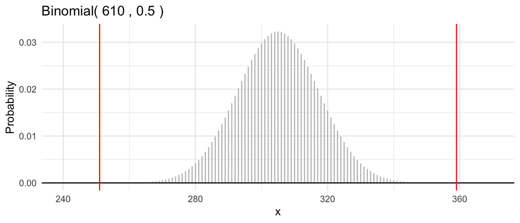

```r
gbinom(610, 0.5, a = 240, b = 370, color = "gray") +
  geom_binom_density(610, 0.5, a = 240, b = 251, color = "red") +
  geom_binom_density(610, 0.5, a = 359, b = 370, color = "red") +
  geom_vline(xintercept = c(251, 359), color = "red")
```

- The p-value is the sum of probabilities at the red lines or further from the mean, which is too small to see visually.
  5. Repeat Problem 3, but use the data for all trials **without a partner** for an assumed universal parameter $p_2 = p_{\text{no partner}}$, using a statistical model for $X_2$, the total number of prosocial choices made without a partner present in the experiment.

> [hypotheses]

> [model]

> [sampling distribution]

> [outcomes]

> [p-value]

> [conclusion]

#### Solution

> [hypotheses]

$H_0: p_2 = 0.5$  
$H_a: p_2 \neq 0.5$

> [model]

$X_2 \mid p_2 ~ \sim \text{Binomial}(180, p_2)$

> [sampling distribution]

If $p_2 = 0.5$, then $X_2 \mid p_1 ~ \sim \text{Binomial}(180, 0.5)$

> [outcomes]
- Find values $x$ which are either:
  - at least as far from $\mu = 90$ as the observed $x_1 = 83$, or;
  - values which have a the same or smaller probability under the null model

```r
mu = n2*0.5
mu
```

```
## [1] 90
```

```r
mu - x2
```

```
## [1] 7
```

```r
mu + (mu - x2)
```

```
## [1] 97
```

Outcomes at least as extreme as $x_2 = 83$ are $x \le 83$ or $x \ge 97$.

Similarly,

```r
tibble(x = 0:n2) %>%
  filter(near(dbinom(x, n2, 0.5), dbinom(x2, n2, 0.5)))
```

```
## # A tibble: 2 × 1
##       x
##   <int>
## 1    83
## 2    97
```

> [p-value]

```r
p_value = pbinom(83, n2, 0.5) + (1 - pbinom(96, n2, 0.5))
p_value
```

```
## [1] 0.3325791
```

> [conclusion]

> The observed data is consistent with the probability that the chimpanzee chooses the prosocial choice color with probability 0.5 when there is no partner present ($p = 0.33$, two-sided binomial test).
6. The previous statistical inferences assume a binomial model for the observed number of prosocial choices for trials with and without a partner.

State one criticism where reality may differ from the assumptions, possibly leading to misleading conclusions. (What is an example of an assumption of the binomial model which, in the given context, is questionable?)

#### Solution

Possible answers:

- There are only seven chimpanzees in the experiment and all live in the same social group. These chimpanzees may not be representative of all chimpanzees, including those in other research stations or in the wild.
- In sessions with different partners, the probability of making the prosocial choice may depend on the identity of the actor, the partner, and the relationship between these two individuals
- In the experiment, the behavior of the partner when present may affect the behavior of the actor in subsequent trials.
  7. In a poll from the 2022 election for governor in Wisconsin, 326 out of 679 likely voters responded that they would vote for the incumbent Tony Evers. Using the Agresti-Coull method, find a 95% confidence interval for the proportion of likely voters in Wisconsin who voted vote for Tony Evers in the November 8 election.

Interpret the confidence interval in context.

> [Respond here]

#### Solution

- Use the Agresti-Coull method

```r
n = 679
x = 326
ptilde = (x+2)/(n+4)
se = sqrt(ptilde*(1-ptilde)/(n+4))
z = qnorm(0.975)

ci = ptilde + c(-1,1) * z * se
signif(se, 2)
```

```
## [1] 0.019
```

```r
round(ci, 3)
```

```
## [1] 0.443 0.518
```

> We are 95% confident that the proportion of likely voters in Wisconsin who will vote for Tony Evers for Governor in 2022 is between 44.3% and 51.8%.
8. In a psychological experiment, a reported psychic tries to guess the suit of the cards of a well-shuffled stack of cards which includes many decks shuffled together. You may assume that the suit of each card in order is equally likely to be any one of the four suits and that the suits of the cards are independent of each other.

In guesses of the suits of 100 cards, the psychic correctly guesses the suit 29 times. Conduct a formal hypothesis test to examine the evidence that the psychic can guess the suit of the cards more often than expected. State a model, declare a test statistic, state hypotheses, calculate a one-sided p-value, and report the results in the context of the problem following the format presented in lecture notes.

#### Solution

Let $X$ be the number of cards correctly guessed.

1. Model: $X \mid p \sim \text{Binomial}(100, p)$
2. Test Statistic: $X$
3. Hypotheses: $H_0: p = 0.25$  
   $H_a: p > 0.25$
4. P-value: $\mathsf{P}(X \ge 29)$ under $H_0$ is:

```r
signif(1 - pbinom(28, 100, 0.25), 2)
```

```
## [1] 0.21
```

The p-value is about 0.21.

5. Interpretation

> There is little evidence that the psychic can correctly identify the suit of a randomly chosen card more often than the null percentage of 0.25 ($p = 0.21$, one-sided binomial test).